# Experiment 2: Loan Amount Prediction using Linear Regression

## Train Test Splitting

```python
X_train, X_temp, y_train, y_temp = train_test_split(
    X_scaled, y, test_size=0.4, random_state=42
)
X_val, X_test, y_val, y_test = train_test_split(
    X_temp, y_temp, test_size=0.5, random_state=42
)
```

## Linear Regression

```python
model = LinearRegression()
model.fit(X_train, y_train)
```

```
LinearRegression()
```

```python
y_test_pred = model.predict(X_test)
y_val_pred = model.predict(X_val)
```

```python
from sklearn.model_selection import KFold
from sklearn.metrics import mean_absolute_error, mean_squared_error, r2_score
import numpy as np
```

```python
k = 5
kf = KFold(n_splits=k, shuffle=True, random_state=42)
fold = 1

for train_index, val_index in kf.split(X):
    X_train, X_val = X.iloc[train_index], X.iloc[val_index]
    y_train, y_val = y.iloc[train_index], y.iloc[val_index]

    model.fit(X_train, y_train)
    y_pred = model.predict(X_val)

    mae = mean_absolute_error(y_val, y_pred)
    mse = mean_squared_error(y_val, y_pred)
    rmse = np.sqrt(mse)
    r2 = r2_score(y_val, y_pred)

    print(f"Fold {fold}")
    print(f"MAE: {mae}")
    print(f"MSE: {mse}")
    print(f"RMSE: {rmse}")
    print(f"R2: {r2}\n")

    fold += 1
```

```
Fold 1
MAE: 21668.788576722698
MSE: 950006999.3224033
RMSE: 30822.183558638466
R2: 0.5867618940930974

Fold 2
MAE: 21911.342227108264
MSE: 979780685.871628
RMSE: 31301.448622573815
R2: 0.5687379911760008

Fold 3
MAE: 22390.51978237663
MSE: 1064500884.1712316
RMSE: 32626.689751968886
R2: 0.5401321966927393

Fold 4
MAE: 21792.861226730343
MSE: 995687416.1477817
RMSE: 31554.514988314775
R2: 0.5765013795818466

Fold 5
MAE: 21031.1658267761
MSE: 879954596.5274839
RMSE: 29664.028663138186
R2: 0.6101864207806889
```

```python
print("Test Set Metrics")
print("MSE:", mean_squared_error(y_test, y_test_pred))
print("RMSE:",np.sqrt(mean_squared_error(y_test, y_test_pred)))
print("MAE:", mean_absolute_error(y_test, y_test_pred))
print("R2 Score:", r2_score(y_test, y_test_pred))

print("\nValidation Set Metrics")
print("MSE:", mean_squared_error(y_val, y_val_pred))
print("RMSE:",np.sqrt(mean_squared_error(y_val, y_val_pred)))
print("MAE:", mean_absolute_error(y_val, y_val_pred))
print("R2 Score:", r2_score(y_val, y_val_pred))
```

```
Test Set Metrics
MSE: 984611884.4087155
RMSE: 31378.52584824079
MAE: 21871.684221674237
R2 Score: 0.559605840628398

Validation Set Metrics
MSE: 3491900139.9687433
RMSE: 59092.30186723769
MAE: 45397.60926458234
R2 Score: -0.5468867339397039
```

## 6) Visualize the Plots

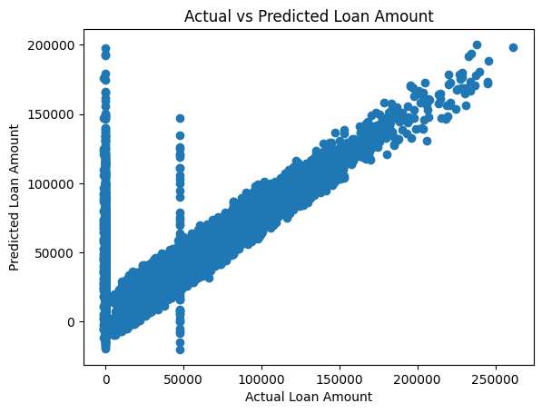

```python
plt.scatter(y_test, y_test_pred)
plt.xlabel("Actual Loan Amount")
plt.ylabel("Predicted Loan Amount")
plt.title("Actual vs Predicted Loan Amount")
plt.show()
```

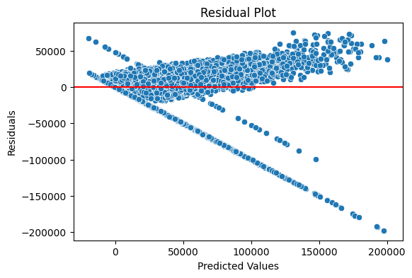

```python
residuals = y_test - y_test_pred

plt.figure(figsize=(6,4))
sns.scatterplot(x=y_test_pred, y=residuals)
plt.axhline(0, color='red')
plt.title("Residual Plot")
plt.xlabel("Predicted Values")
plt.ylabel("Residuals")
plt.show()
```

## 7) Cross-Validation Results Table

**Table 1: Cross-Validation Results (K = 5)**

| Fold | MAE | MSE | RMSE | R² Score |
| --- | --- | --- | --- | --- |
| Fold 1 | 21668.79 | 950006999.32 | 30822.18 | 0.5868 |
| Fold 2 | 21911.34 | 979780685.87 | 31301.45 | 0.5687 |
| Fold 3 | 22390.52 | 1064500884.17 | 32626.69 | 0.5401 |
| Fold 4 | 21792.86 | 995687416.15 | 31554.51 | 0.5765 |
| Fold 5 | 21031.17 | 879954596.53 | 29664.03 | 0.6102 |
| **Average** | **21758.94** | **973986116.41** | **31193.77** | **0.5765** |

**Table 2: Summary of Results for Loan Amount Prediction**

[output not shown]

## 8) Best practice for Linear Regression

- Clean the dataset and handle missing values
- Remove or treat outliers
- Select only relevant features
- Avoid multicollinearity between input variables
- Normalize or scale features if ranges differ
- Split data into training and testing sets
- Train the model on training data only
- Evaluate using MSE, RMSE, and R² score
- Check linear regression assumptions
- Interpret coefficients clearly
- Use Linear Regression as a baseline model
- Document results for reproducibility

## 9)Learning Outcomes

- Learned to apply **Linear Regression** for loan amount prediction.
- Understood **data preprocessing** and **feature selection**.
- Used **train–test split** and **K-Fold Cross-Validation** for evaluation.
- Evaluated model performance using **MAE, MSE, RMSE, and R²**.
- Interpreted results using **residual** and **predicted vs actual** plots.